# Deep_Neural_Network_Bank_Churn_Prediction

#### SMOTE and RUS (Base Model)

```python
# To oversample and undersample data
from imblearn.over_sampling import SMOTE
from imblearn.under_sampling import RandomUnderSampler
```

```python
# Creating oversampled training data
sm = SMOTE(sampling_strategy=1, k_neighbors=5, random_state=1)
x_train_over, y_train_over = sm.fit_resample(x_train, y_train)

# Creating undersampled training data
rus = RandomUnderSampler(random_state=1)
x_train_under, y_train_under = rus.fit_resample(x_train, y_train)
```

##### SMOTE Base Model

```python
backend.clear_session()
np.random.seed(1)
random.seed(1)
tf.random.set_seed(1)
```

```python
# Initializing the model
model_0_over = Sequential()
model_0_over.add(Dense(64, activation='relu', input_dim=x_train.shape[1]))
model_0_over.add(Dense(32, activation='relu'))
model_0_over.add(Dense(1, activation='sigmoid'))

# Compliling the model with binary crossentropy as loss, SGD as optimizer and recall as metric
model_0_over.compile(loss = 'binary_crossentropy', optimizer = 'SGD', metrics = tf.keras.metrics.Recall())
# Printing the summary of the model
model_0_over.summary()
```

```
Model: "sequential"
_________________________________________________________________
 Layer (type)                Output Shape              Param #
=================================================================
 dense (Dense)               (None, 64)                640

 dense_1 (Dense)             (None, 32)                2080

 dense_2 (Dense)             (None, 1)                 33

=================================================================
Total params: 2,753
Trainable params: 2,753
Non-trainable params: 0
_________________________________________________________________
```

```python
# Defining Early Stopping
es_cb = callbacks.EarlyStopping(monitor='val_loss',
                                min_delta=0.001,
                                patience=10)

# Fitting the model on training data
history_0_over = model_0_over.fit(x_train_over,
                                  y_train_over,
                                  validation_data = (x_val, y_val),
                                  epochs = 100,
                                  callbacks = es_cb,
                                  verbose = 0)
```

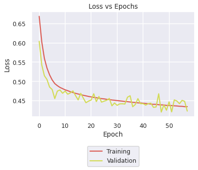

```python
# Visualizing the loss versus epoch for validation and training data sets
plt.plot(history_0_over.history['loss'])
plt.plot(history_0_over.history['val_loss'])
plt.title('Loss vs Epochs')
plt.ylabel('Loss')
plt.xlabel('Epoch')
plt.legend(['Training', 'Validation'], loc = 'lower center',  bbox_to_anchor=(0.5, -0.5))
plt.show()
```

The loss reduction is worse than before and is fairly noisey. Let's check the classification report.

```
Best Threshold=0.507315, G-Mean=0.792
```

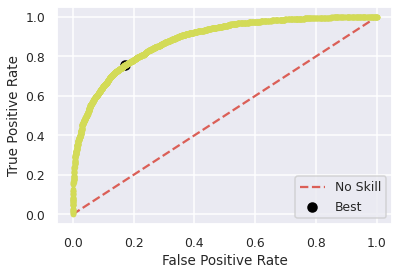

```python
# predict probabilities
yhat0_over = model_0_over.predict(x_train_over)
# keep probabilities for the positive outcome only
yhat0_over = yhat0_over[:, 0]
# calculate roc curves
fpr, tpr, thresholds0_over = roc_curve(y_train_over, yhat0_over)
# calculate the g-mean for each threshold
gmeans0_over = np.sqrt(tpr * (1-fpr))
# locate the index of the largest g-mean
ix = np.argmax(gmeans0_over)
print('Best Threshold=%f, G-Mean=%.3f' % (thresholds0_over[ix], gmeans0_over[ix]))
# plot the roc curve for the model
pyplot.plot([0,1], [0,1], linestyle='--', label='No Skill')
pyplot.plot(fpr, tpr, marker='.')
pyplot.scatter(fpr[ix], tpr[ix], marker='o', color='black', label='Best')
# axis labels
pyplot.xlabel('False Positive Rate')
pyplot.ylabel('True Positive Rate')
pyplot.legend()
# show the plot
pyplot.show()
```

```python
# Setting the prediction threshold
y_pred_over = model_0_over.predict(x_train_over)
y_pred_over = (y_pred_over > thresholds0_over[ix])
# Viewing the training classification report
cr=metrics.classification_report(y_train_over,y_pred_over)
print('Training Data Classification Report (SMOTE Data):')
print(cr)
```

```
Training Data Classification Report (SMOTE Data):
              precision    recall  f1-score   support

           0       0.77      0.83      0.80      4459
           1       0.81      0.76      0.78      4459

    accuracy                           0.79      8918
   macro avg       0.79      0.79      0.79      8918
weighted avg       0.79      0.79      0.79      8918
```

```python
# Setting the prediction threshold
y_pred_over = model_0_over.predict(x_val)
y_pred_over = (y_pred_over > thresholds0_over[ix])
# Viewing the training classification report
cr=metrics.classification_report(y_val, y_pred_over)
print('Validation Data Classification Report (SMOTE Data):')
print(cr)
```

```
Validation Data Classification Report (SMOTE Data):
              precision    recall  f1-score   support

           0       0.92      0.83      0.88      1911
           1       0.53      0.73      0.61       489

    accuracy                           0.81      2400
   macro avg       0.72      0.78      0.74      2400
weighted avg       0.84      0.81      0.82      2400
```

Recall performance is comparable to the base model, but with a slight reduction of about 2%.

##### RUS Base Model

```python
backend.clear_session()
np.random.seed(1)
random.seed(1)
tf.random.set_seed(1)
```

```python
# Initializing the model
model_0_under = Sequential()
model_0_under.add(Dense(64, activation='relu', input_dim = x_train.shape[1]))
model_0_under.add(Dense(32, activation='relu'))
model_0_under.add(Dense(1, activation='sigmoid'))

# Compliling the model with binary crossentropy as loss, SGD as optimizer and recall as metric
model_0_under.compile(loss = 'binary_crossentropy', optimizer = 'SGD', metrics = tf.keras.metrics.Recall())
# Printing the summary of the model
model_0_under.summary()
```

```
Model: "sequential"
_________________________________________________________________
 Layer (type)                Output Shape              Param #
=================================================================
 dense (Dense)               (None, 64)                640

 dense_1 (Dense)             (None, 32)                2080

 dense_2 (Dense)             (None, 1)                 33

=================================================================
Total params: 2,753
Trainable params: 2,753
Non-trainable params: 0
_________________________________________________________________
```

```python
# Defining Early Stopping
es_cb = callbacks.EarlyStopping(monitor='val_loss',
                                min_delta=0.001,
                                patience=10)

# Fitting the model on training data
history_0_under = model_0_under.fit(x_train_under,
                                    y_train_under,
                                    validation_data = (x_val, y_val),
                                    epochs = 100,
                                    verbose = 0)
```

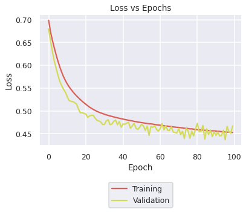

```python
# Visualizing the loss versus epoch for validation and training data sets
plt.plot(history_0_under.history['loss'])
plt.plot(history_0_under.history['val_loss'])
plt.title('Loss vs Epochs')
plt.ylabel('Loss')
plt.xlabel('Epoch')
plt.legend(['Training', 'Validation'], loc = 'lower center',  bbox_to_anchor=(0.5, -0.5))
plt.show()
```

The loss has not improved in comparison to SMOTE or the base model.

```
Best Threshold=0.523352, G-Mean=0.795
```

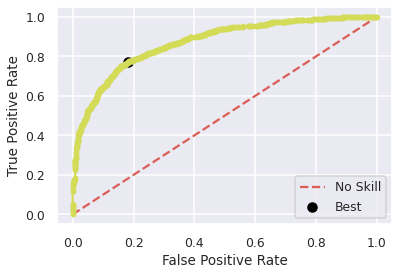

```python
# predict probabilities
yhat0_under = model_0_under.predict(x_train_under)
# keep probabilities for the positive outcome only
yhat0_under = yhat0_under[:, 0]
# calculate roc curves
fpr, tpr, thresholds0_under = roc_curve(y_train_under, yhat0_under)
# calculate the g-mean for each threshold
gmeans0_under = np.sqrt(tpr * (1-fpr))
# locate the index of the largest g-mean
ix = np.argmax(gmeans0_under)
print('Best Threshold=%f, G-Mean=%.3f' % (thresholds0_under[ix], gmeans0_under[ix]))
# plot the roc curve for the model
pyplot.plot([0,1], [0,1], linestyle='--', label='No Skill')
pyplot.plot(fpr, tpr, marker='.')
pyplot.scatter(fpr[ix], tpr[ix], marker='o', color='black', label='Best')
# axis labels
pyplot.xlabel('False Positive Rate')
pyplot.ylabel('True Positive Rate')
pyplot.legend()
# show the plot
pyplot.show()
```

```python
# Setting the prediction threshold
y_pred_under = model_0_under.predict(x_train_under)
y_pred_under = (y_pred_under > thresholds0_under[ix])
# Viewing the training classification report
cr=metrics.classification_report(y_train_under,y_pred_under)
print('Training Data Classification Report (RUS Data):')
print(cr)
```

```
Training Data Classification Report (RUS Data):
              precision    recall  f1-score   support

           0       0.78      0.82      0.80      1141
           1       0.81      0.77      0.79      1141

    accuracy                           0.79      2282
   macro avg       0.80      0.79      0.79      2282
weighted avg       0.80      0.79      0.79      2282
```

```python
# Setting the prediction threshold
y_pred_under = model_0_under.predict(x_val)
y_pred_under = (y_pred_under > thresholds0_under[ix])
# Viewing the training classification report
cr=metrics.classification_report(y_val, y_pred_under)
print('Validation Data Classification Report (RUS Data):')
print(cr)
```

```
Validation Data Classification Report (RUS Data):
              precision    recall  f1-score   support

           0       0.93      0.80      0.86      1911
           1       0.49      0.75      0.59       489

    accuracy                           0.79      2400
   macro avg       0.71      0.77      0.72      2400
weighted avg       0.84      0.79      0.80      2400
```

Both SMOTE and RUS have acheived similar performance in recall with the base model. However, there is significantly more noise in RUS and both did not perform as well as the base model in terms of loss reduction. Therefore, we will continue to use the base training data for future models.

#### Model 2

We have already seen that the base model prefers a lower number of layers and unaltered training data. However there are some other hyperparameters such as different optimizers, batch sizes, learning rates, dropout rates, batch normalization, etc. that have yet to be tested.

We'll quickly check two more optimizers (Adam and RMSprop) with our base model to see if they perform better with the data. Then we'll perform a more extensive search all other hyperparameters.

##### Exploring Adam and RMSprop optimizers

```python
backend.clear_session()
np.random.seed(1)
random.seed(1)
tf.random.set_seed(1)
```

```python
# Initializing the model
model_0_Adam = Sequential()
model_0_Adam.add(Dense(64, activation='relu', input_dim=x_train.shape[1]))
model_0_Adam.add(Dense(32, activation='relu'))
model_0_Adam.add(Dense(1, activation='sigmoid'))

# Compiling the model
model_0_Adam.compile(loss = 'binary_crossentropy', optimizer = 'Adam', metrics = tf.keras.metrics.Recall())
# Printing the summary of the model
model_0_Adam.summary()
```

```
Model: "sequential"
_________________________________________________________________
 Layer (type)                Output Shape              Param #
=================================================================
 dense (Dense)               (None, 64)                640

 dense_1 (Dense)             (None, 32)                2080

 dense_2 (Dense)             (None, 1)                 33

=================================================================
Total params: 2,753
Trainable params: 2,753
Non-trainable params: 0
_________________________________________________________________
```

```python
# Defining Early Stopping
es_cb = callbacks.EarlyStopping(monitor='val_loss',
                                min_delta=0.001,
                                patience=10)

# Fitting the model on train data
history_0_Adam = model_0_Adam.fit(x_train,
                                  y_train,
                                  validation_data = (x_val, y_val),
                                  epochs = 100,
                                  callbacks = es_cb,
                                  verbose = 0)
```

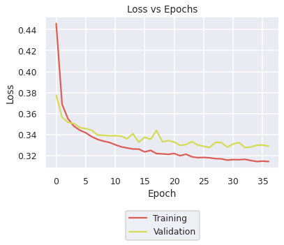

```python
# Visualizing the loss versus epoch for validation and training data sets
plt.plot(history_0_Adam.history['loss'])
plt.plot(history_0_Adam.history['val_loss'])
plt.title('Loss vs Epochs')
plt.ylabel('Loss')
plt.xlabel('Epoch')
plt.legend(['Training', 'Validation'], loc = 'lower center',  bbox_to_anchor=(0.5, -0.5))
plt.show()
```

The loss on the model with the Adam optimizer is comparable to the base model. However, the validation loss appears to be slightly overfit. Lets check the classification report.

```
Best Threshold=0.245328, G-Mean=0.801
```

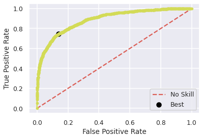

```python
# predict probabilities
yhat0_Adam = model_0_Adam.predict(x_train)
# keep probabilities for the positive outcome only
yhat0_Adam = yhat0_Adam[:, 0]
# calculate roc curves
fpr, tpr, thresholds0_Adam = roc_curve(y_train, yhat0_Adam)
# calculate the g-mean for each threshold
gmeans0_Adam = np.sqrt(tpr * (1-fpr))
# locate the index of the largest g-mean
ix = np.argmax(gmeans0_Adam)
print('Best Threshold=%f, G-Mean=%.3f' % (thresholds0_Adam[ix], gmeans0_Adam[ix]))
# plot the roc curve for the model
pyplot.plot([0,1], [0,1], linestyle='--', label='No Skill')
pyplot.plot(fpr, tpr, marker='.')
pyplot.scatter(fpr[ix], tpr[ix], marker='o', color='black', label='Best')
# axis labels
pyplot.xlabel('False Positive Rate')
pyplot.ylabel('True Positive Rate')
pyplot.legend()
# show the plot
pyplot.show()
```

```python
# Setting the prediction threshold
y_pred_Adam = model_0_Adam.predict(x_train)
y_pred_Adam = (y_pred_Adam > thresholds0_Adam[ix])
# Viewing the training classification report
cr=metrics.classification_report(y_train,y_pred_Adam)
print('Training Data Classification Report (Adam Optimizer):')
print(cr)
```

```
Training Data Classification Report (Adam Optimizer):
              precision    recall  f1-score   support

           0       0.93      0.86      0.89      4459
           1       0.58      0.74      0.65      1141

    accuracy                           0.84      5600
   macro avg       0.75      0.80      0.77      5600
weighted avg       0.86      0.84      0.84      5600
```

```python
# Setting the prediction threshold
y_pred_Adam = model_0_Adam.predict(x_val)
y_pred_Adam = (y_pred_Adam > thresholds0_Adam[ix])
# Viewing the training classification report
cr=metrics.classification_report(y_val,y_pred_Adam)
print('Validation Data Classification Report (Adam Optimizer):')
print(cr)
```

```
Validation Data Classification Report (Adam Optimizer):
              precision    recall  f1-score   support

           0       0.92      0.85      0.89      1911
           1       0.55      0.71      0.62       489

    accuracy                           0.82      2400
   macro avg       0.74      0.78      0.75      2400
weighted avg       0.85      0.82      0.83      2400
```

```python
backend.clear_session()
np.random.seed(1)
random.seed(1)
tf.random.set_seed(1)
```

```python
# Initializing the model
model_0_RMSprop = Sequential()
model_0_RMSprop.add(Dense(64, activation='relu', input_dim=x_train.shape[1]))
model_0_RMSprop.add(Dense(32, activation='relu'))
model_0_RMSprop.add(Dense(1, activation='sigmoid'))

# Compiling the model
model_0_RMSprop.compile(loss = 'binary_crossentropy',
                        optimizer = 'RMSprop',
                        metrics = tf.keras.metrics.Recall())

# Printing the summary of the model
model_0_RMSprop.summary()
```

```
Model: "sequential"
_________________________________________________________________
 Layer (type)                Output Shape              Param #
=================================================================
 dense (Dense)               (None, 64)                640

 dense_1 (Dense)             (None, 32)                2080

 dense_2 (Dense)             (None, 1)                 33

=================================================================
Total params: 2,753
Trainable params: 2,753
Non-trainable params: 0
_________________________________________________________________
```

```python
# Defining Early Stopping
es_cb = callbacks.EarlyStopping(monitor='val_loss',
                                min_delta=0.001,
                                patience=10)

# Fitting the model on train data
history_0_RMSprop = model_0_RMSprop.fit(x_train,
                                        y_train,
                                        validation_data = (x_val, y_val),
                                        epochs = 100,
                                        callbacks = es_cb,
                                        verbose = 0)
```

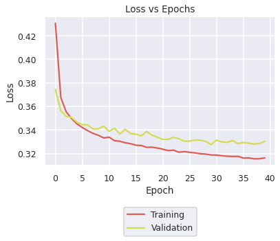

```python
# Visualizing the loss versus epoch for validation and training data sets
plt.plot(history_0_RMSprop.history['loss'])
plt.plot(history_0_RMSprop.history['val_loss'])
plt.title('Loss vs Epochs')
plt.ylabel('Loss')
plt.xlabel('Epoch')
plt.legend(['Training', 'Validation'], loc = 'lower center',  bbox_to_anchor=(0.5, -0.5))
plt.show()
```

The loss on the model with the RMSprop optimizer is also comparable to the base model. The validation loss shows that this model may be overfit. Let's check the classification report.

```
Best Threshold=0.161820, G-Mean=0.797
```

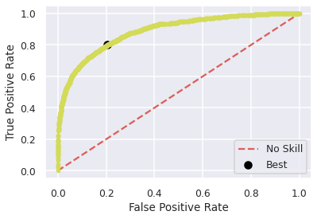

```python
# predict probabilities
yhat0_RMSprop = model_0_RMSprop.predict(x_train)
# keep probabilities for the positive outcome only
yhat0_RMSprop = yhat0_RMSprop[:, 0]
# calculate roc curves
fpr, tpr, thresholds0_RMSprop = roc_curve(y_train, yhat0_RMSprop)
# calculate the g-mean for each threshold
gmeans0_RMSprop = np.sqrt(tpr * (1-fpr))
# locate the index of the largest g-mean
ix = np.argmax(gmeans0_RMSprop)
print('Best Threshold=%f, G-Mean=%.3f' % (thresholds0_RMSprop[ix], gmeans0_RMSprop[ix]))
# plot the roc curve for the model
pyplot.plot([0,1], [0,1], linestyle='--', label='No Skill')
pyplot.plot(fpr, tpr, marker='.')
pyplot.scatter(fpr[ix], tpr[ix], marker='o', color='black', label='Best')
# axis labels
pyplot.xlabel('False Positive Rate')
pyplot.ylabel('True Positive Rate')
pyplot.legend()
# show the plot
pyplot.show()
```

```python
# Setting the prediction threshold
y_pred_RMSprop = model_0_RMSprop.predict(x_train)
y_pred_RMSprop = (y_pred_RMSprop > thresholds0_RMSprop[ix])
# Viewing the training classification report
cr=metrics.classification_report(y_train,y_pred_RMSprop)
print('Training Data Classification Report (RMSprop Optimizer):')
print(cr)
```

```
Training Data Classification Report (RMSprop Optimizer):
              precision    recall  f1-score   support

           0       0.94      0.79      0.86      4459
           1       0.50      0.80      0.61      1141

    accuracy                           0.80      5600
   macro avg       0.72      0.80      0.74      5600
weighted avg       0.85      0.80      0.81      5600
```

```python
# Setting the prediction threshold
y_pred_RMSprop = model_0_RMSprop.predict(x_val)
y_pred_RMSprop = (y_pred_RMSprop > thresholds0_RMSprop[ix])
# Viewing the training classification report
cr=metrics.classification_report(y_val,y_pred_RMSprop)
print('Validation Data Classification Report (RMSprop Optimizer):')
print(cr)
```

```
Validation Data Classification Report (RMSprop Optimizer):
              precision    recall  f1-score   support

           0       0.93      0.79      0.86      1911
           1       0.49      0.78      0.60       489

    accuracy                           0.79      2400
   macro avg       0.71      0.79      0.73      2400
weighted avg       0.84      0.79      0.81      2400
```